# IODS course project

Maiju Tanskanen

## About this project

On this course I will *hopefully* learn some basic tools and methods to do research with open data.

Here’s a link to my GiHub repository: https://github.com/maijutanskanen/IODS-project

# Regression and model validation

*In this exercise, linear regression analysis is used to find out significant predictors of exam points of a statistics course exam.*

## Data

The data used in the analysis contains 166 cases and 7 variables. Variables “deep”, “stra”, and “surf” are combined variables indicating respondent’s learning strategies: deep, strategic and surface learning. “Attitude” indicates global attitude towards statistics, and “Points” indicates respondent’s exam points. In addition, age and gender are used as basic sociodemographic variables. Descriptive statistics of the data are displayed on the table above. There are considerably more females on the data: 110 vs. 56 males. As for learning strategies, the respondents tend to have slightly higher overall score on deep learning than other strategies.

```r
summary(analysis_data)
```

```
##  gender       Age           Attitude          deep            stra
##  F:110   Min.   :17.00   Min.   :1.400   Min.   :1.583   Min.   :1.250
##  M: 56   1st Qu.:21.00   1st Qu.:2.600   1st Qu.:3.333   1st Qu.:2.625
##          Median :22.00   Median :3.200   Median :3.667   Median :3.188
##          Mean   :25.51   Mean   :3.143   Mean   :3.680   Mean   :3.121
##          3rd Qu.:27.00   3rd Qu.:3.700   3rd Qu.:4.083   3rd Qu.:3.625
##          Max.   :55.00   Max.   :5.000   Max.   :4.917   Max.   :5.000
##       surf           Points
##  Min.   :1.583   Min.   : 7.00
##  1st Qu.:2.417   1st Qu.:19.00
##  Median :2.833   Median :23.00
##  Mean   :2.787   Mean   :22.72
##  3rd Qu.:3.167   3rd Qu.:27.75
##  Max.   :4.333   Max.   :33.00
```

The plot below demonstrates the distributions of the variables and the relationships between them on males (blue) and females (red). As for exam points, attitude has the strongest correlation. Overall, there are minor differences on the distributions and relationships between genders but nothing outstanding.

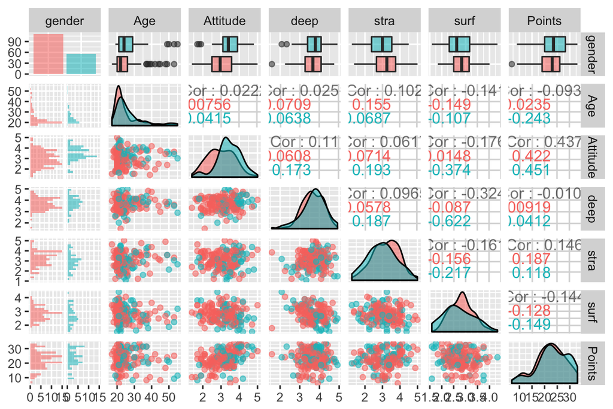

```r
p <- ggpairs(analysis_data, mapping = aes(col= gender, alpha = 0.3),
lower = list(combo = wrap("facethist", bins = 20)))
```

## Initial regression model

Initially, linear regression model is built with three explanatory variables: attitude, age and deep learning. The results of the analysis are displayed on the matrix below. Regarding the explanatory variables, only attitude is statistically significant (p<0.001) with beta-value of 3.59 indicating that increase of one unit of attitude increases the exam points by 3.59 in the model.

```r
my_model1 <- lm(Points ~ Attitude + Age + deep, data = analysis_data)

summary(my_model1)
```

```
##
## Call:
## lm(formula = Points ~ Attitude + Age + deep, data = analysis_data)
##
## Residuals:
##     Min      1Q  Median      3Q     Max
## -17.206  -3.430   0.204   3.979  10.950
##
## Coefficients:
##             Estimate Std. Error t value Pr(>|t|)
## (Intercept) 15.60773    3.38966   4.605 8.32e-06 ***
## Attitude     3.59413    0.56959   6.310 2.56e-09 ***
## Age         -0.07716    0.05322  -1.450    0.149
## deep        -0.60275    0.75031  -0.803    0.423
## ---
## Signif. codes:  0 '***' 0.001 '**' 0.01 '*' 0.05 '.' 0.1 ' ' 1
##
## Residual standard error: 5.307 on 162 degrees of freedom
## Multiple R-squared:  0.2043, Adjusted R-squared:  0.1896
## F-statistic: 13.87 on 3 and 162 DF,  p-value: 4.305e-08
```

## Fitted regression model

In the fitted linear regression model, age and deep learning are removed from the analysis as non-significant. In this model, attitude remains statistically significant (p<0.001) beta-value being 3.52. The r-square value of 0.19 indicates that the model explains about 19 % of the variability of the dependent “points” variable.

```r
my_model2 <- lm(Points ~ Attitude, data = analysis_data)
summary(my_model2)
```

```
##
## Call:
## lm(formula = Points ~ Attitude, data = analysis_data)
##
## Residuals:
##      Min       1Q   Median       3Q      Max
## -16.9763  -3.2119   0.4339   4.1534  10.6645
##
## Coefficients:
##             Estimate Std. Error t value Pr(>|t|)
## (Intercept)  11.6372     1.8303   6.358 1.95e-09 ***
## Attitude      3.5255     0.5674   6.214 4.12e-09 ***
## ---
## Signif. codes:  0 '***' 0.001 '**' 0.01 '*' 0.05 '.' 0.1 ' ' 1
##
## Residual standard error: 5.32 on 164 degrees of freedom
## Multiple R-squared:  0.1906, Adjusted R-squared:  0.1856
## F-statistic: 38.61 on 1 and 164 DF,  p-value: 4.119e-09
```

The plots below can be interpreted to demonstrate how well the model fits the data. In the QQ-plot (down left), the points seem to follow the line quite well, which indicates that the errors of the model are quite normally distributed. There does not seen to be any patterns on the scatter plot of fitted values and residuals, which indicates that the errors in the model have constant variance. In the residuals vs. leverage plot there is no single observation standing out, which means that there are no observations having an unusually high impact. Based on these plots, the model seems to fit the data quite well.

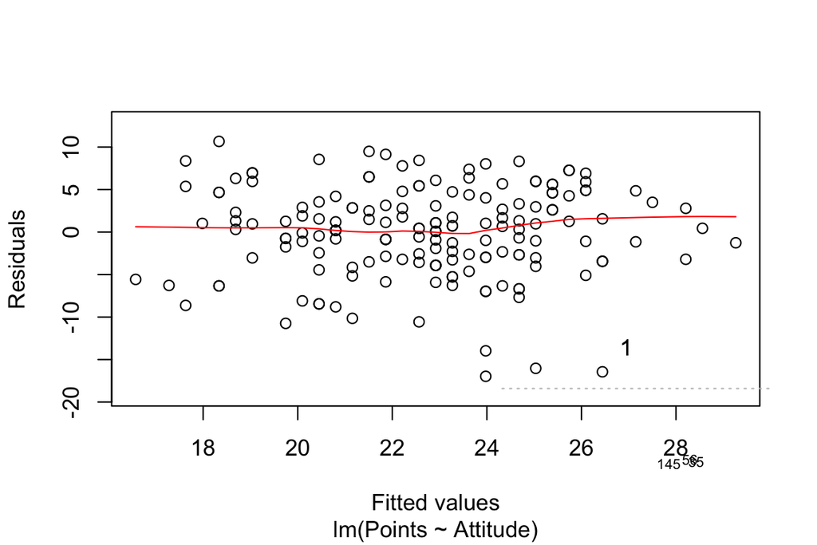

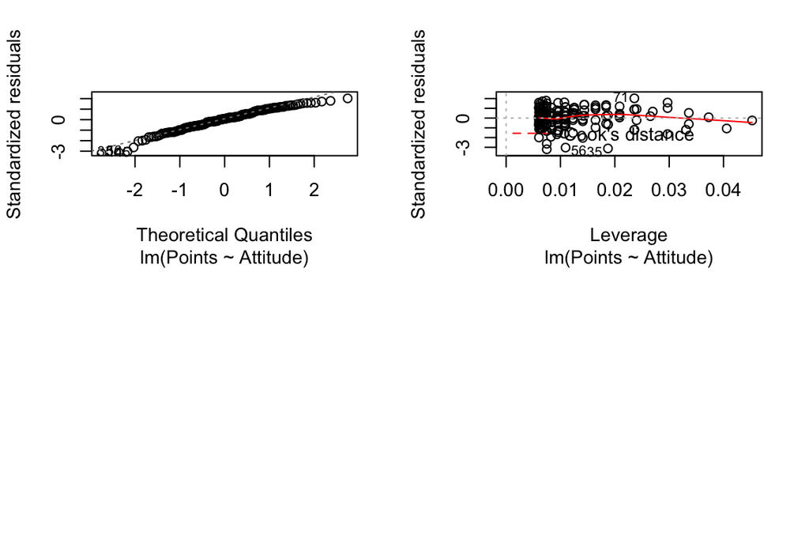

```r
plot(my_model2, which = c(1, 2, 5), par(mfrow = c(2,2)))
```

# Logistic regression

In this exercise, logistic regression is used to define predictors of alcohol consumption among portuguese students.

## Data

The data used in the analysis contains 382 observations and 35 variables related to family, freetime and school. The names of the variables are displayed in the matrix below.

```r
colnames(alc)
```

```
##  [1] "school"     "sex"        "age"        "address"    "famsize"
##  [6] "Pstatus"    "Medu"       "Fedu"       "Mjob"       "Fjob"
## [11] "reason"     "nursery"    "internet"   "guardian"   "traveltime"
## [16] "studytime"  "failures"   "schoolsup"  "famsup"     "paid"
## [21] "activities" "higher"     "romantic"   "famrel"     "freetime"
## [26] "goout"      "Dalc"       "Walc"       "health"     "absences"
## [31] "G1"         "G2"         "G3"         "alc_use"    "high_use"
```

### Dependent variable

Variable “high_use” indicating high achocol consumption will be used as the dependent variable in the analysis, and the plot below demonstrates its distribution.

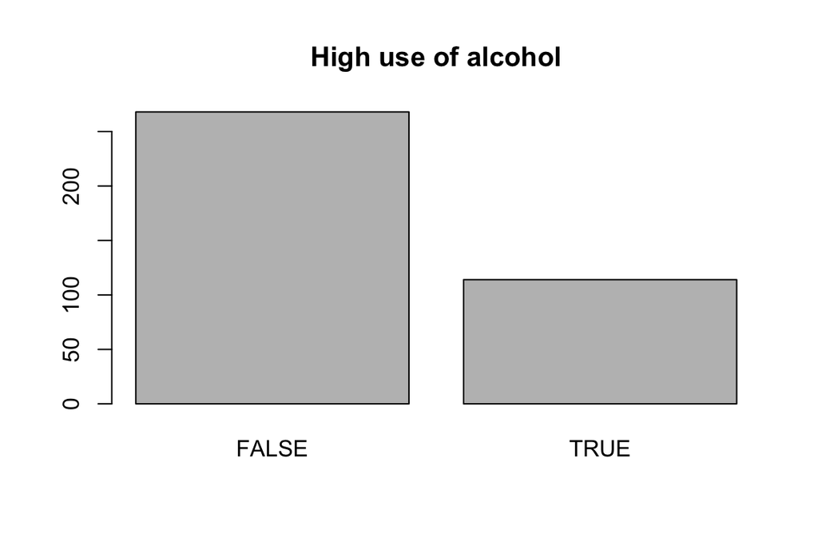

```r
counts <- table(alc$high_use)
barplot(counts, main = "High use of alcohol")
```

### Predictors

Below, high alcohol consumption is cross-tabulated with gender and relationship status (yes or no) which will be used as predictors.

```r
table1 <- table(alc$high_use, alc$sex)
table1
```

```
##
##           F   M
##   FALSE 156 112
##   TRUE   42  72
```

```r
table2 <- table(alc$high_use, alc$romantic)
table2
```

```
##
##          no yes
##   FALSE 180  88
##   TRUE   81  33
```

The barplots below display the distributions of the two other predictors, school absences and going out with friends.

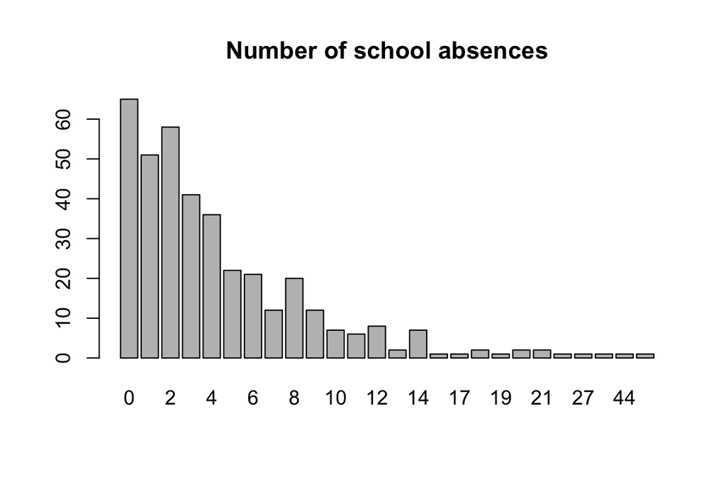

```r
counts3 <- table(alc$absences)
barplot(counts3, main = "Number of school absences")
```

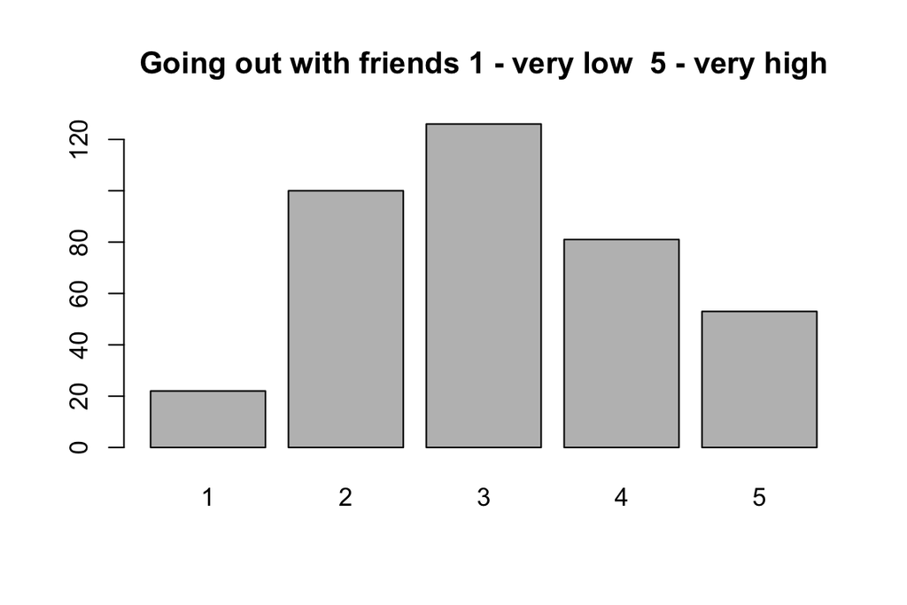

```r
counts4 <- table(alc$goout)
barplot(counts4, main = "Going out with friends 1 - very low  5 - very high")
```

The boxpot demonstrates the relationship between high achohol consumption and school absences grouped by gender.

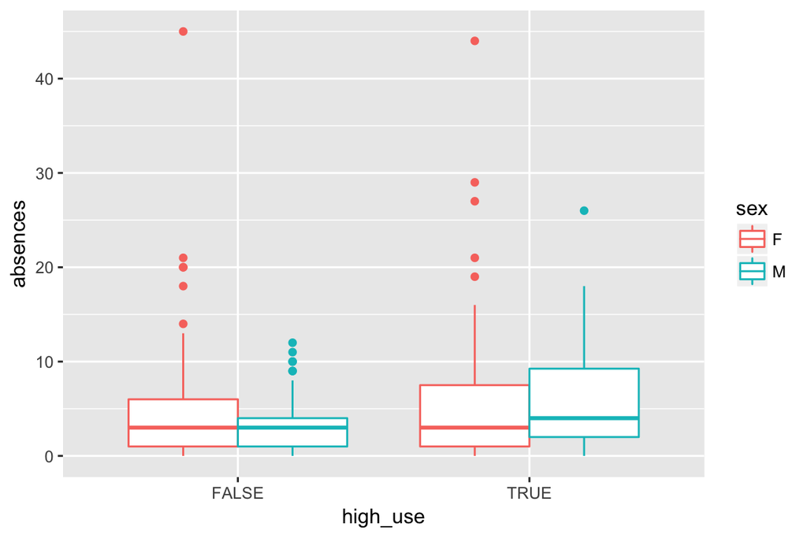

```r
g1 <- ggplot(alc, aes(x = high_use, y = absences))
g1 + geom_boxplot(aes(col = sex))
```

### Hypotheses

Before the analysis, four hypotheses are made: *1) Male gender is a statistically significant predictor of high alcohol consumption.* *2) Being in a relationship is a statistically significant predictor of high alcohol consumption.* *3) Having a lot of school absences predicts high alcohol consumption on a statistically significant level.* *4) Going out with friends a lot predicts high alcohol consumption on a statistically significant level.*

## Analysis

### Initial analysis

Initially, all the four predictors described above are used as predictors of high alcohol consumption in a logical regression model.

```r
m <- glm(high_use ~  romantic + goout + sex + absences, data = alc, family = "binomial")
summary(m)
```

```
##
## Call:
## glm(formula = high_use ~ romantic + goout + sex + absences, family = "binomial",
##     data = alc)
##
## Deviance Residuals:
##     Min       1Q   Median       3Q      Max
## -1.8278  -0.8092  -0.5396   0.8106   2.5440
##
## Coefficients:
##             Estimate Std. Error z value Pr(>|z|)
## (Intercept) -4.08370    0.47911  -8.524  < 2e-16 ***
## romanticyes -0.27418    0.27613  -0.993 0.320744
## goout        0.73079    0.11965   6.108 1.01e-09 ***
## sexM         0.94289    0.25522   3.694 0.000220 ***
## absences     0.08626    0.02245   3.842 0.000122 ***
## ---
## Signif. codes:  0 '***' 0.001 '**' 0.01 '*' 0.05 '.' 0.1 ' ' 1
##
## (Dispersion parameter for binomial family taken to be 1)
##
##     Null deviance: 465.68  on 381  degrees of freedom
## Residual deviance: 386.75  on 377  degrees of freedom
## AIC: 396.75
##
## Number of Fisher Scoring iterations: 4
```

The results show that relationship status is not a statistically significant predictor, and thus the second hypothesis is rejected as false. The variable is removed from the analysis and the model is fitted with three predictors: going out, gender and absences.

### Fitted model

```r
m2 <- glm(high_use ~ goout + sex + absences, data = alc, family = "binomial")
summary(m2)
```

```
##
## Call:
## glm(formula = high_use ~ goout + sex + absences, family = "binomial",
##     data = alc)
##
## Deviance Residuals:
##     Min       1Q   Median       3Q      Max
## -1.7871  -0.8153  -0.5446   0.8357   2.4740
##
## Coefficients:
##             Estimate Std. Error z value Pr(>|z|)
## (Intercept) -4.16317    0.47506  -8.764  < 2e-16 ***
## goout        0.72981    0.11970   6.097 1.08e-09 ***
## sexM         0.95872    0.25459   3.766 0.000166 ***
## absences     0.08418    0.02237   3.764 0.000167 ***
## ---
## Signif. codes:  0 '***' 0.001 '**' 0.01 '*' 0.05 '.' 0.1 ' ' 1
##
## (Dispersion parameter for binomial family taken to be 1)
##
##     Null deviance: 465.68  on 381  degrees of freedom
## Residual deviance: 387.75  on 378  degrees of freedom
## AIC: 395.75
##
## Number of Fisher Scoring iterations: 4
```

In the second model, all the three predictors are statistically significant (p<0.001). The odd ratios (OR) below are interpreted to understand the results and to varify or falsify the three remaining hypotheses:

1. The first hypothesis seems to be true: male gender is a statistically significant predictor of high alcohol consumption. Compared to females, males have a 2.61 times higher risk of high alcohol consumption.
2. The third hypothesis is varified as well: having a lot of school absences predicts high alcohol consumption on a statistically significant level with an odd ratio of 1.09. This means, for example, that having ten more absences increases risk of high alcohol consumption by 2.32 times.
3. Also, the fourth hypothesis is varified: going out with friends a lot predicts high alcohol consumption on a statistically significant level with an odd ratio of 2.07. Thus, those going out most (5) have a 18.5 times higher risk of high alcohol consumption compared to those who go out least (1).

```r
OR <- coef(m2) %>% exp

CI <- confint(m2) %>% exp

cbind(OR, CI)
```

```
##                     OR       2.5 %     97.5 %
## (Intercept) 0.01555815 0.005885392 0.03804621
## goout       2.07468346 1.650182481 2.64111050
## sexM        2.60835292 1.593132148 4.33151387
## absences    1.08782902 1.042458467 1.13933894
```

## Testing the model

The predictive power of the model is tested. With the code below, variable “probability”, indicating the probability of high alcohol cosumption being true according to the model, and variable “prediction” indicating that according to the model there is more than a 50 % chance of high alcohol cosumption being true, are added to the data.

### Real values vs. predicted values

The cross-tabulation matrix below shows that 302 of 382 observations in the data ( 79 %) are correctly classified. The plot below visualizes this.

```r
probabilities <- predict(m2, type = "response")

alc <- mutate(alc, probability = probabilities)

alc <- mutate(alc, prediction = (probability > 0.5))

table(high_use = alc$high_use, prediction = alc$prediction)
```

```
##         prediction
## high_use FALSE TRUE
##    FALSE   253   15
##    TRUE     65   49
```

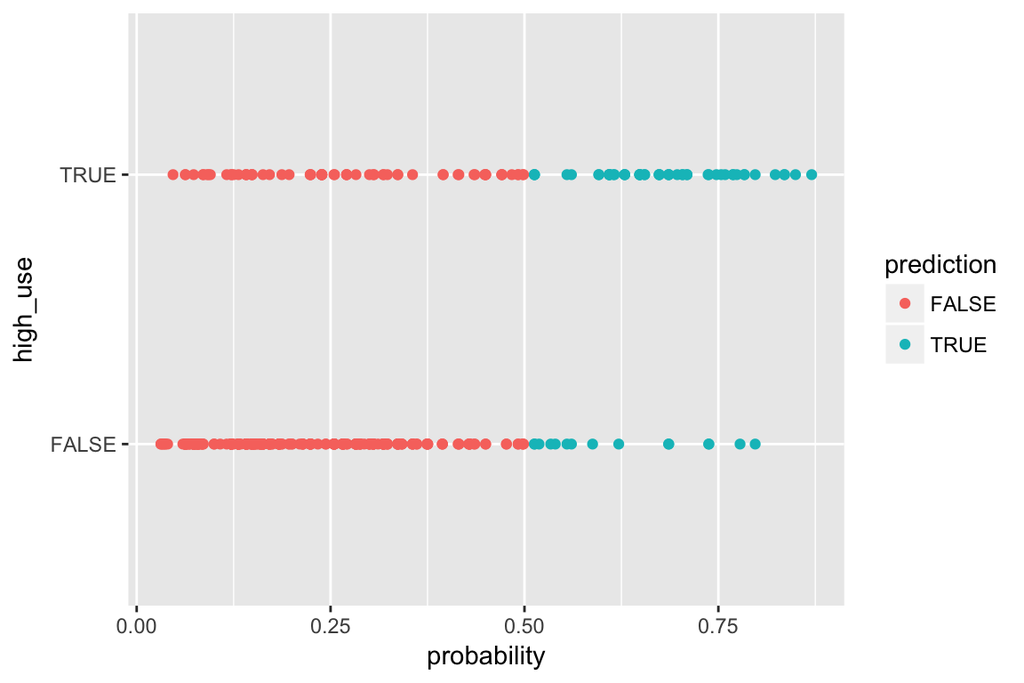

```r
g <- ggplot(alc, aes(x = probability, y =high_use , col = prediction))
g + geom_point()
```

### Classification error

The result of using a loss function on the model shows that there is a 0.21 classification error in the model meaning that the model classifies uncorrectly 21 % of the cases. When guessing that there is a 0.4 chance for every observation in the data to have high alcohol consumption, the error is 30 %. Thus, the model works slightly better than a guess.

```r
loss_func <- function(class, prob) {
  n_wrong <- abs(class - prob) > 0.5
  mean(n_wrong)
}

loss_func(class = alc$high_use, prob = alc$probability)
```

```
## [1] 0.2094241
```

```r
alc$guess <- 0.4
loss_func(class = alc$high_use, prob = alc$guess)
```

```
## [1] 0.2984293
```

### Cross-validation

Finally, the model is tested with cross-validation. The 10-fold cross-validation of the model results in a 0.21 error. Thus, my model seems to be better than the one in DataCamp, woop.

```r
library(boot)
cv <- cv.glm(data = alc, cost = loss_func, glmfit = m2, K = 10)

cv$delta[1]
```

```
## [1] 0.2068063
```

# Clustering and classification

In this exercise, linear discriminant analysis (LDA) and k-means clustering are used to classify data based on crime rate and to find clusters in the data.

## Data

The data used in this exercise is the Boston dataset from R’s MASS package. The data contains information about housing in the area of Boston and it has 506 observations and 14 variables. The summaries of the variables are displayed in the matrix below and more information about them can be found [here](https://stat.ethz.ch/R-manual/R-devel/library/MASS/html/Boston.html).

The correlation matrix demonstrates the relationships between the variables. Some of the variables have a clear positive or negative correlation, which seems obvious based on the nature of the variables. As for the summary matrix, it can be seen that the variables are very differently distributed compared to each other as different units of measurement are, of course, used.

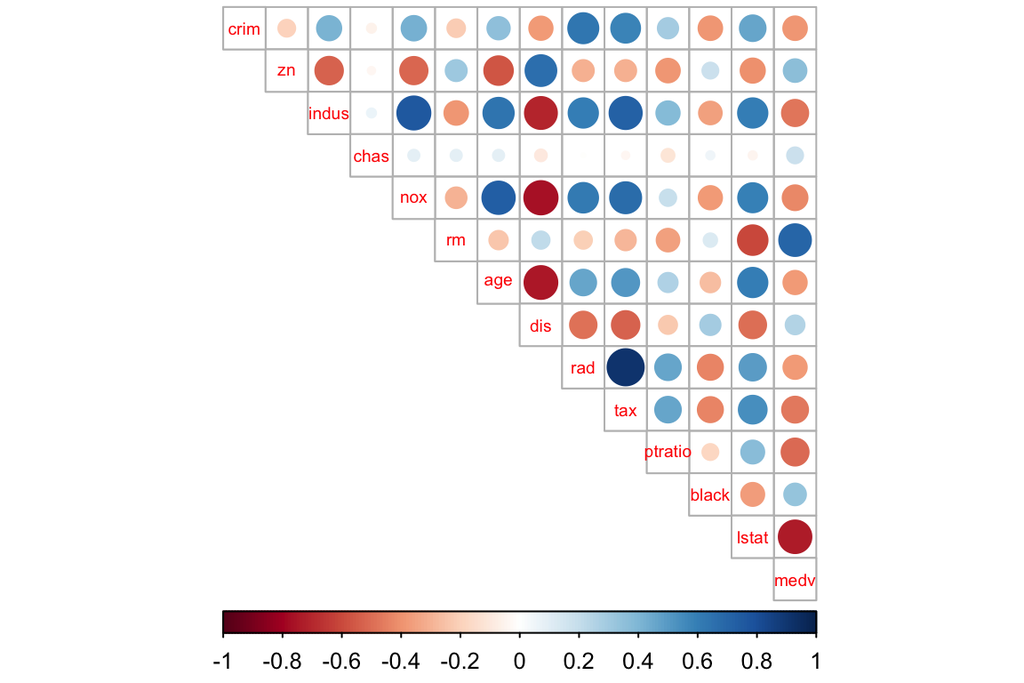

```r
cor_matrix<-cor(Boston)
cor_matrix %>% round( digits=2) %>% corrplot(method="circle", type = "upper", cl.pos = "b", tl.pos = "d", tl.cex = 0.6)
```

```r
summary(Boston)
```

```
##       crim                zn             indus            chas
##  Min.   : 0.00632   Min.   :  0.00   Min.   : 0.46   Min.   :0.00000
##  1st Qu.: 0.08204   1st Qu.:  0.00   1st Qu.: 5.19   1st Qu.:0.00000
##  Median : 0.25651   Median :  0.00   Median : 9.69   Median :0.00000
##  Mean   : 3.61352   Mean   : 11.36   Mean   :11.14   Mean   :0.06917
##  3rd Qu.: 3.67708   3rd Qu.: 12.50   3rd Qu.:18.10   3rd Qu.:0.00000
##  Max.   :88.97620   Max.   :100.00   Max.   :27.74   Max.   :1.00000
##       nox               rm             age              dis
##  Min.   :0.3850   Min.   :3.561   Min.   :  2.90   Min.   : 1.130
##  1st Qu.:0.4490   1st Qu.:5.886   1st Qu.: 45.02   1st Qu.: 2.100
##  Median :0.5380   Median :6.208   Median : 77.50   Median : 3.207
##  Mean   :0.5547   Mean   :6.285   Mean   : 68.57   Mean   : 3.795
##  3rd Qu.:0.6240   3rd Qu.:6.623   3rd Qu.: 94.08   3rd Qu.: 5.188
##  Max.   :0.8710   Max.   :8.780   Max.   :100.00   Max.   :12.127
##       rad              tax           ptratio          black
##  Min.   : 1.000   Min.   :187.0   Min.   :12.60   Min.   :  0.32
##  1st Qu.: 4.000   1st Qu.:279.0   1st Qu.:17.40   1st Qu.:375.38
##  Median : 5.000   Median :330.0   Median :19.05   Median :391.44
##  Mean   : 9.549   Mean   :408.2   Mean   :18.46   Mean   :356.67
##  3rd Qu.:24.000   3rd Qu.:666.0   3rd Qu.:20.20   3rd Qu.:396.23
##  Max.   :24.000   Max.   :711.0   Max.   :22.00   Max.   :396.90
##      lstat            medv
##  Min.   : 1.73   Min.   : 5.00
##  1st Qu.: 6.95   1st Qu.:17.02
##  Median :11.36   Median :21.20
##  Mean   :12.65   Mean   :22.53
##  3rd Qu.:16.95   3rd Qu.:25.00
##  Max.   :37.97   Max.   :50.00
```

### Scaling the data

For the purpose of later analysis, the whole data is standardized. As the summary matrix shows, the mean of every variable is now 0.

```r
boston_scaled <- scale(Boston)
summary(boston_scaled)
```

```
##       crim                 zn               indus
##  Min.   :-0.419367   Min.   :-0.48724   Min.   :-1.5563
##  1st Qu.:-0.410563   1st Qu.:-0.48724   1st Qu.:-0.8668
##  Median :-0.390280   Median :-0.48724   Median :-0.2109
##  Mean   : 0.000000   Mean   : 0.00000   Mean   : 0.0000
##  3rd Qu.: 0.007389   3rd Qu.: 0.04872   3rd Qu.: 1.0150
##  Max.   : 9.924110   Max.   : 3.80047   Max.   : 2.4202
##       chas              nox                rm               age
##  Min.   :-0.2723   Min.   :-1.4644   Min.   :-3.8764   Min.   :-2.3331
##  1st Qu.:-0.2723   1st Qu.:-0.9121   1st Qu.:-0.5681   1st Qu.:-0.8366
##  Median :-0.2723   Median :-0.1441   Median :-0.1084   Median : 0.3171
##  Mean   : 0.0000   Mean   : 0.0000   Mean   : 0.0000   Mean   : 0.0000
##  3rd Qu.:-0.2723   3rd Qu.: 0.5981   3rd Qu.: 0.4823   3rd Qu.: 0.9059
##  Max.   : 3.6648   Max.   : 2.7296   Max.   : 3.5515   Max.   : 1.1164
##       dis               rad               tax             ptratio
##  Min.   :-1.2658   Min.   :-0.9819   Min.   :-1.3127   Min.   :-2.7047
##  1st Qu.:-0.8049   1st Qu.:-0.6373   1st Qu.:-0.7668   1st Qu.:-0.4876
##  Median :-0.2790   Median :-0.5225   Median :-0.4642   Median : 0.2746
##  Mean   : 0.0000   Mean   : 0.0000   Mean   : 0.0000   Mean   : 0.0000
##  3rd Qu.: 0.6617   3rd Qu.: 1.6596   3rd Qu.: 1.5294   3rd Qu.: 0.8058
##  Max.   : 3.9566   Max.   : 1.6596   Max.   : 1.7964   Max.   : 1.6372
##      black             lstat              medv
##  Min.   :-3.9033   Min.   :-1.5296   Min.   :-1.9063
##  1st Qu.: 0.2049   1st Qu.:-0.7986   1st Qu.:-0.5989
##  Median : 0.3808   Median :-0.1811   Median :-0.1449
##  Mean   : 0.0000   Mean   : 0.0000   Mean   : 0.0000
##  3rd Qu.: 0.4332   3rd Qu.: 0.6024   3rd Qu.: 0.2683
##  Max.   : 0.4406   Max.   : 3.5453   Max.   : 2.9865
```

### Creating a categorical variable

After scaling, the continuous “crim”, indicating per capita crime rate by town, is recoded into four categories, and the original variable is replaced by the new categorical “crime” variable.

```r
scaled_crim <- boston_scaled$crim
bins <- quantile(scaled_crim)
crime <- cut(scaled_crim, breaks = bins, include.lowest = TRUE)
crime <- factor(crime, labels = c("low", "med_low", "med_high", "high"))
table(crime)
```

```
## crime
##      low  med_low med_high     high
##      127      126      126      127
```

```r
boston_scaled <- dplyr::select(boston_scaled, -crim)
boston_scaled <- data.frame(boston_scaled, crime)
```

## Linear Discriminant Analysis

### Creating train and test sets

Before the analysis, a train set containing 80 % of the observations in the data and a test set with 20 % of the observations are created.

```r
n <- 506
ind <- sample(n,  size = n * 0.8)
train <- boston_scaled[ind,]
test <- boston_scaled[-ind,]
```

### Analysis

Linear discriminant analysis (LDA) is used to find the variables that separate the classes of the categorical “crime” variable. The results of the analysis are displayed below.

The plot below visualizes the results of the analysis.

```r
lda.fit <- lda(crime ~ ., data = train)
lda.fit
```

```
## Call:
## lda(crime ~ ., data = train)
##
## Prior probabilities of groups:
##       low   med_low  med_high      high
## 0.2623762 0.2549505 0.2277228 0.2549505
##
## Group means:
##                  zn      indus        chas        nox         rm
## low       0.9323571 -0.9152240 -0.12375925 -0.8895992  0.4410566
## med_low  -0.1238252 -0.2319621  0.03346513 -0.5428884 -0.2017608
## med_high -0.4117391  0.2699607  0.02723291  0.4429385  0.1048508
## high     -0.4872402  1.0170891 -0.04298342  1.0624200 -0.4828458
##                 age        dis        rad        tax     ptratio
## low      -0.8490707  0.8534461 -0.6893371 -0.7430275 -0.46620442
## med_low  -0.2778277  0.3434978 -0.5414397 -0.4467010 -0.06466658
## med_high  0.4217520 -0.4032314 -0.4076377 -0.2698295 -0.26212674
## high      0.7935913 -0.8543671  1.6384176  1.5142626  0.78111358
##                black       lstat        medv
## low       0.38321636 -0.76798041  0.52377288
## med_low   0.31149093 -0.04034579 -0.07028284
## med_high  0.05954774 -0.02007955  0.15763683
## high     -0.76477842  0.90421205 -0.71105017
##
## Coefficients of linear discriminants:
##                 LD1         LD2         LD3
## zn       0.04533626  0.70232203 -0.92367406
## indus    0.03461026 -0.29721340  0.31816614
## chas    -0.05214541 -0.00443475  0.30567322
## nox      0.36411437 -0.85998242 -1.36020101
## rm      -0.06551632 -0.11909000 -0.21762003
## age      0.22517997 -0.23498516 -0.06642023
## dis     -0.06885410 -0.27960747  0.29471779
## rad      3.16186430  1.00846873 -0.03387588
## tax      0.03069761 -0.03454838  0.47043624
## ptratio  0.09319103 -0.01837146 -0.30228066
## black   -0.11856563  0.04154040  0.13251744
## lstat    0.22213644 -0.08698922  0.51088191
## medv     0.16072460 -0.29188348 -0.18192443
##
## Proportion of trace:
##    LD1    LD2    LD3
## 0.9450 0.0380 0.0169
```

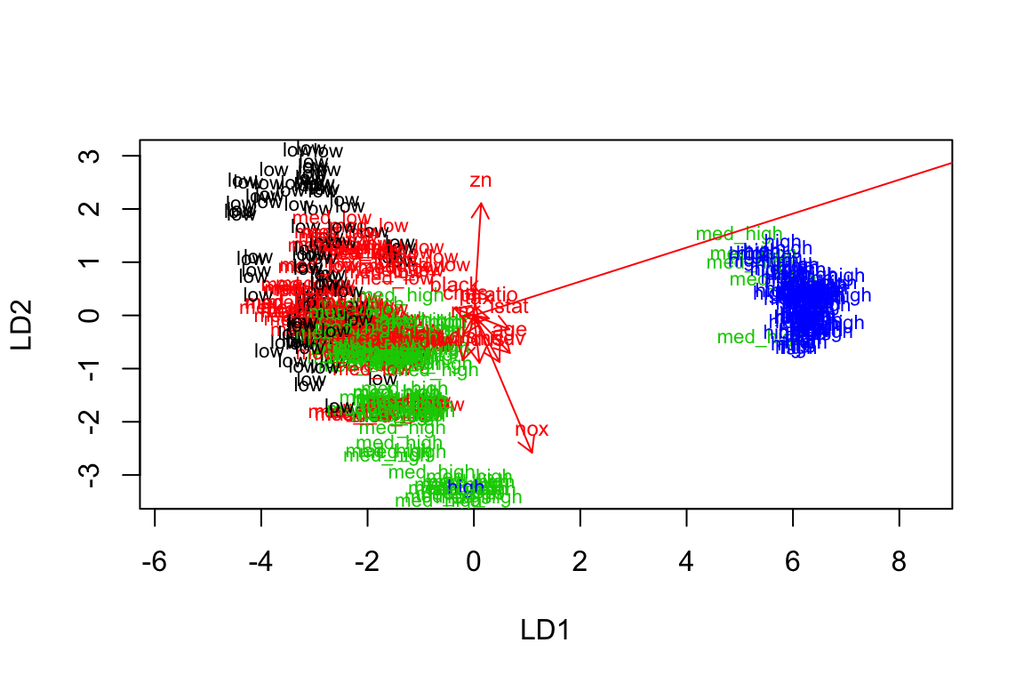

```r
lda.arrows <- function(x, myscale = 1, arrow_heads = 0.1, color = "red", tex = 0.75, choices = c(1,2)){
  heads <- coef(x)
  arrows(x0 = 0, y0 = 0,
         x1 = myscale * heads[,choices[1]],
         y1 = myscale * heads[,choices[2]], col=color, length = arrow_heads)
  text(myscale * heads[,choices], labels = row.names(heads),
       cex = tex, col=color, pos=3)
}
classes <- as.numeric(train$crime)

plot(lda.fit, dimen = 2, col = classes, pch = classes)
lda.arrows(lda.fit, myscale = 3)
```

### Testing the predictions

```r
correct_classes <- test$crime
test <- dplyr::select(test, -crime)
lda.pred <- predict(lda.fit, newdata = test)
table(correct = correct_classes, predicted = lda.pred$class)
```

```
##           predicted
## correct    low med_low med_high high
##   low       13       7        1    0
##   med_low    8      12        3    0
##   med_high   1      14       18    1
##   high       0       0        0   24
```

## Clustering by k-means

The original Boston data (with the continuous “crim” variable) is scaled and the Euclidean distances between the observations are counted in order to use the k-means algorithm. After trying with a few different number of clusters, it seems like two clusters separate the data the best. The scatter plot matrix below demonstrates the clusters in two dimensions. It seems like at least variables “tax” and “rad” are clear separators.

```r
boston <- scale(Boston)
boston <- as.data.frame(boston)
dist_eu <- dist(boston)
summary(dist_eu)
```

```
##    Min. 1st Qu.  Median    Mean 3rd Qu.    Max.
##  0.1343  3.4620  4.8240  4.9110  6.1860 14.4000
```

[figure not shown]

```r
km <-kmeans(dist_eu, centers = 2)
pairs(Boston, col = km$cluster)
```

### LDA on clusters

```r
km2 <-kmeans(dist_eu, centers = 3)
lda.fit2 <- lda(km2$cluster ~ ., data = boston)
lda.fit2
```

```
## Call:
## lda(km2$cluster ~ ., data = boston)
##
## Prior probabilities of groups:
##         1         2         3
## 0.2075099 0.4545455 0.3379447
##
## Group means:
##         crim         zn      indus        chas        nox         rm
## 1 -0.3928010  1.3229917 -0.9259301  0.44009859 -0.7598391  1.0574260
## 2 -0.3836903 -0.2417220 -0.3961699 -0.27232907 -0.4622965 -0.1362230
## 3  0.7572682 -0.4872402  1.1014137  0.09605458  1.0883702 -0.4660727
##          age        dis        rad        tax     ptratio      black
## 1 -0.7717354  0.8205368 -0.5913924 -0.6414244 -0.95738042  0.3438442
## 2 -0.2436777  0.2523399 -0.5819051 -0.6076728  0.02174424  0.3090727
## 3  0.8016262 -0.8432429  1.1458150  1.2111947  0.55861853 -0.6268442
##        lstat        medv
## 1 -0.8818772  1.15932490
## 2 -0.2420506 -0.03505142
## 3  0.8670686 -0.66472098
##
## Coefficients of linear discriminants:
##                 LD1         LD2
## crim    -0.02888613  0.15059842
## zn       0.19021173  1.19748109
## indus    0.74772214 -0.01199683
## chas     0.09725660  0.47536603
## nox      0.84565514  0.38351766
## rm      -0.09589403  0.48812607
## age     -0.13170086 -0.08411580
## dis      0.06277612  0.11575438
## rad      0.76263747 -0.17554557
## tax      0.62543787  0.69318490
## ptratio  0.18516563 -0.11053258
## black   -0.07029190 -0.05865397
## lstat    0.28604098  0.56753341
## medv     0.02298635  0.77450418
##
## Proportion of trace:
##    LD1    LD2
## 0.7909 0.2091
```

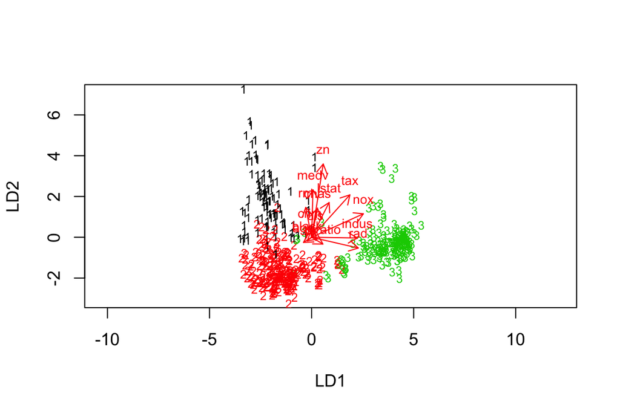

```r
lda.arrows <- function(x, myscale = 1, arrow_heads = 0.1, color = "red", tex = 0.75, choices = c(1,2)){
  heads <- coef(x)
  arrows(x0 = 0, y0 = 0,
         x1 = myscale * heads[,choices[1]],
         y1 = myscale * heads[,choices[2]], col=color, length = arrow_heads)
  text(myscale * heads[,choices], labels = row.names(heads),
       cex = tex, col=color, pos=3)
}

classes2 <- as.numeric(km2$cluster)

plot(lda.fit2, dimen = 2, col = classes2, pch = classes2)
lda.arrows(lda.fit2, myscale = 3)
```

# Dimensionality reduction techniques

In this exercise, dimensionality reduction techniques are used to find components and connections in two different datasets and in that way reduce number of dimensions in them.

## Principal component analysis (PCA)

### Data

The “human” dataset contains different indicators of human development and gender inequality. In the modified dataset used in the PCA exercise, there are 155 observations (countries) and the following 8 variables:

“eduratio”: famale/male ratio of population with secondary education

“labourratio”: female/male ratio of labour force participation

“life”: life expectancy at birth

“expedu”: expected years of education

“gni”: gross national income (GNI) per capita

“matmort”: maternal mortality ratio

“adobirth”: adolescent birth rate

“parliament”: % of seats in parliament held by women

The summaries of the variables are displayed in the matrix below, and the plot below visualizes the distributions of the variables and displays the correlations between them. There are some rather big and quite obvious positive/negative correlations between some of the variables; for example, life expectancy correlates negatively with maternal mortality whereas expected years of education has a positive correlation with it.

```r
summary(human)
```

```
##     eduratio       labourratio          life           expedu
##  Min.   :0.1717   Min.   :0.1857   Min.   :49.00   Min.   : 5.40
##  1st Qu.:0.7264   1st Qu.:0.5984   1st Qu.:66.30   1st Qu.:11.25
##  Median :0.9375   Median :0.7535   Median :74.20   Median :13.50
##  Mean   :0.8529   Mean   :0.7074   Mean   :71.65   Mean   :13.18
##  3rd Qu.:0.9968   3rd Qu.:0.8535   3rd Qu.:77.25   3rd Qu.:15.20
##  Max.   :1.4967   Max.   :1.0380   Max.   :83.50   Max.   :20.20
##       gni            matmort          adobirth        parliament
##  Min.   :   581   Min.   :   1.0   Min.   :  0.60   Min.   : 0.00
##  1st Qu.:  4198   1st Qu.:  11.5   1st Qu.: 12.65   1st Qu.:12.40
##  Median : 12040   Median :  49.0   Median : 33.60   Median :19.30
##  Mean   : 17628   Mean   : 149.1   Mean   : 47.16   Mean   :20.91
##  3rd Qu.: 24512   3rd Qu.: 190.0   3rd Qu.: 71.95   3rd Qu.:27.95
##  Max.   :123124   Max.   :1100.0   Max.   :204.80   Max.   :57.50
```

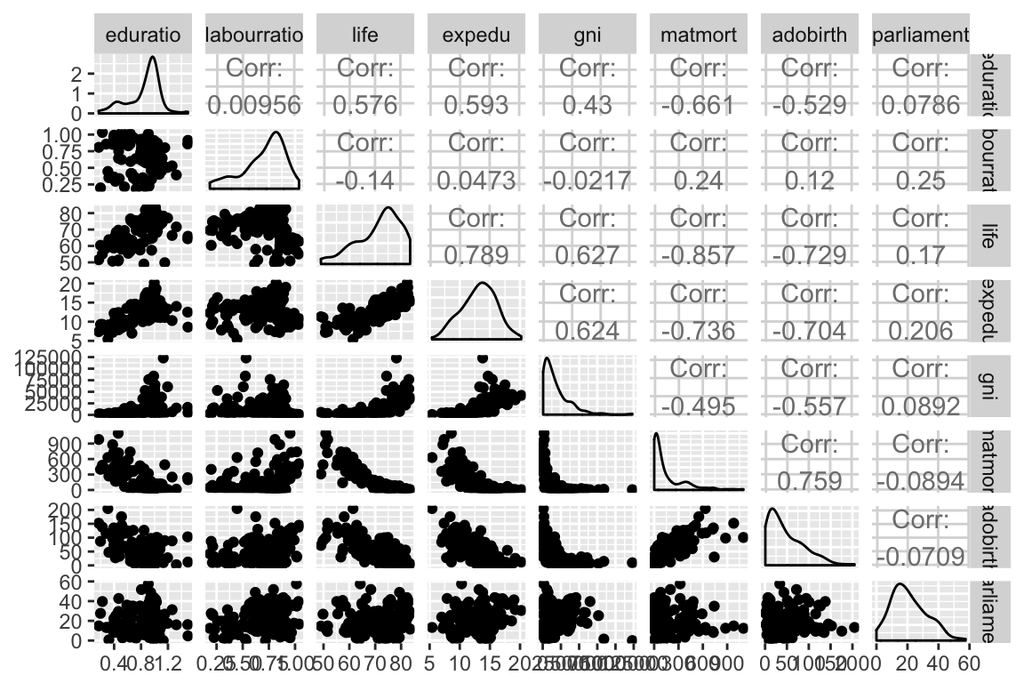

```r
ggpairs(human)
```

### Analysis

*Non-standardized data*

At first, principal component analysis is run on the non-standardized data. The results of the analysis can be seen below.

```r
pca_human <- prcomp(human)
pca_human
```

```
## Standard deviations:
## [1] 1.854416e+04 1.855219e+02 2.518701e+01 1.145441e+01 3.766241e+00
## [6] 1.565912e+00 1.912052e-01 1.591112e-01
##
## Rotation:
##                       PC1           PC2           PC3           PC4
## eduratio    -5.607472e-06  0.0006713951 -3.412027e-05 -2.736326e-04
## labourratio  2.331945e-07 -0.0002819357  5.302884e-04 -4.692578e-03
## life        -2.815823e-04  0.0283150248  1.294971e-02 -6.752684e-02
## expedu      -9.562910e-05  0.0075529759  1.427664e-02 -3.313505e-02
## gni         -9.999832e-01 -0.0057723054 -5.156742e-04  4.932889e-05
## matmort      5.655734e-03 -0.9916320120  1.260302e-01 -6.100534e-03
## adobirth     1.233961e-03 -0.1255502723 -9.918113e-01  5.301595e-03
## parliament  -5.526460e-05  0.0032317269 -7.398331e-03 -9.971232e-01
##                       PC5           PC6           PC7           PC8
## eduratio    -0.0022935252  2.180183e-02  6.998623e-01  7.139410e-01
## labourratio  0.0022190154  3.264423e-02  7.132267e-01 -7.001533e-01
## life         0.9865644425 -1.453515e-01  5.380452e-03  2.281723e-03
## expedu       0.1431180282  9.882477e-01 -3.826887e-02  7.776451e-03
## gni         -0.0001135863 -2.711698e-05 -8.075191e-07 -1.176762e-06
## matmort      0.0266373214  1.695203e-03  1.355518e-04  8.371934e-04
## adobirth     0.0188618600  1.273198e-02 -8.641234e-05 -1.707885e-04
## parliament  -0.0716401914 -2.309896e-02 -2.642548e-03  2.680113e-03
```

```r
s <- summary(pca_human)
pca_pr <- round(100*s$importance[2, ], digits = 1)



paste0(names(pca_pr), " (", pca_pr, "%)")
```

```
## [1] "PC1 (100%)" "PC2 (0%)"   "PC3 (0%)"   "PC4 (0%)"   "PC5 (0%)"
## [6] "PC6 (0%)"   "PC7 (0%)"   "PC8 (0%)"
```

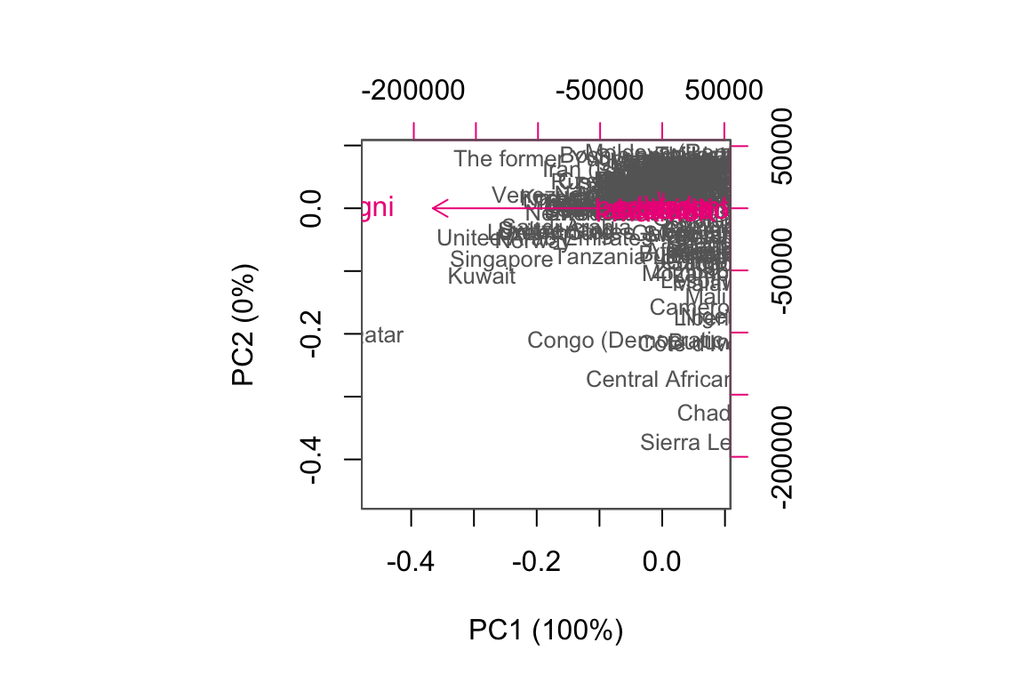

```r
pc_lab <-paste0(names(pca_pr), " (", pca_pr, "%)")
biplot(pca_human, cex = c(0.8, 1), col = c("grey40", "deeppink2"), xlab = pc_lab[1], ylab = pc_lab[2])
```

The first component (PC1) that is highly impacted by gross national income (GNI) per capita captures all the variance in the data when PCA is run using non-standardized data. So, the results can be interpreted as GNI explaining all the differences in human development and gender inequality between countries.

*Standardized data*

As PCA gives more importance to variables with large variance, the data is standardized to run PCA again in order to get more plausible results.

```r
human_std <- scale(human)
summary(human_std)
```

```
##     eduratio        labourratio           life             expedu
##  Min.   :-2.8189   Min.   :-2.6247   Min.   :-2.7188   Min.   :-2.7378
##  1st Qu.:-0.5233   1st Qu.:-0.5484   1st Qu.:-0.6425   1st Qu.:-0.6782
##  Median : 0.3503   Median : 0.2316   Median : 0.3056   Median : 0.1140
##  Mean   : 0.0000   Mean   : 0.0000   Mean   : 0.0000   Mean   : 0.0000
##  3rd Qu.: 0.5958   3rd Qu.: 0.7350   3rd Qu.: 0.6717   3rd Qu.: 0.7126
##  Max.   : 2.6646   Max.   : 1.6632   Max.   : 1.4218   Max.   : 2.4730
##       gni             matmort           adobirth         parliament
##  Min.   :-0.9193   Min.   :-0.6992   Min.   :-1.1325   Min.   :-1.8203
##  1st Qu.:-0.7243   1st Qu.:-0.6496   1st Qu.:-0.8394   1st Qu.:-0.7409
##  Median :-0.3013   Median :-0.4726   Median :-0.3298   Median :-0.1403
##  Mean   : 0.0000   Mean   : 0.0000   Mean   : 0.0000   Mean   : 0.0000
##  3rd Qu.: 0.3712   3rd Qu.: 0.1932   3rd Qu.: 0.6030   3rd Qu.: 0.6127
##  Max.   : 5.6890   Max.   : 4.4899   Max.   : 3.8344   Max.   : 3.1850
```

The results of the second analysis can be seen below.

```r
pca_human2 <- prcomp(human_std)
pca_human2
```

```
## Standard deviations:
## [1] 2.0708380 1.1397204 0.8750485 0.7788630 0.6619563 0.5363061 0.4589994
## [8] 0.3222406
##
## Rotation:
##                     PC1         PC2         PC3         PC4        PC5
## eduratio    -0.35664370  0.03796058 -0.24223089  0.62678110 -0.5983585
## labourratio  0.05457785  0.72432726 -0.58428770  0.06199424  0.2625067
## life        -0.44372240 -0.02530473  0.10991305 -0.05834819  0.1628935
## expedu      -0.42766720  0.13940571 -0.07340270 -0.07020294  0.1659678
## gni         -0.35048295  0.05060876 -0.20168779 -0.72727675 -0.4950306
## matmort      0.43697098  0.14508727 -0.12522539 -0.25170614 -0.1800657
## adobirth     0.41126010  0.07708468  0.01968243  0.04986763 -0.4672068
## parliament  -0.08438558  0.65136866  0.72506309  0.01396293 -0.1523699
##                     PC6         PC7         PC8
## eduratio     0.17713316  0.05773644  0.16459453
## labourratio -0.03500707 -0.22729927 -0.07304568
## life        -0.42242796 -0.43406432  0.62737008
## expedu      -0.38606919  0.77962966 -0.05415984
## gni          0.11120305 -0.13711838 -0.16961173
## matmort      0.17370039  0.35380306  0.72193946
## adobirth    -0.76056557 -0.06897064 -0.14335186
## parliament   0.13749772  0.00568387 -0.02306476
```

```r
s2 <- summary(pca_human2)

pca_pr2 <- round(100*s2$importance[2, ], digits = 1)



paste0(names(pca_pr2), " (", pca_pr2, "%)")
```

```
## [1] "PC1 (53.6%)" "PC2 (16.2%)" "PC3 (9.6%)"  "PC4 (7.6%)"  "PC5 (5.5%)"
## [6] "PC6 (3.6%)"  "PC7 (2.6%)"  "PC8 (1.3%)"
```

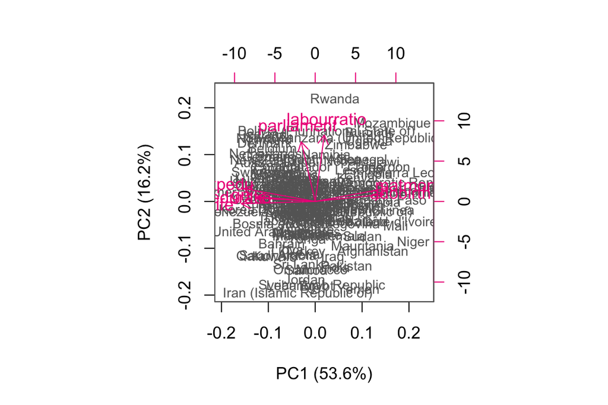

```r
pc_lab2 <-paste0(names(pca_pr2), " (", pca_pr2, "%)")


biplot(pca_human2, cex = c(0.8, 1), col = c("grey40", "deeppink2"), xlab = pc_lab2[1], ylab = pc_lab2[2])
```

Due to scaling, the results of the second analysis are quite different from the first one in which variable “gni” had a great importance because of its large scale compared to the other variables. In the second analysis, the variables have more equal loadings.

The first component (PC1) captures 53.6 % of the variance in the data. As the plot above shows, this component is highly loaded with variables indicating life expectancy, maternal mortality, adolescent birth rate, expected years of education and education ratio between genders. As for the second component (PC2), which captures 16.2 % of the variance, percentage of women in parliament and ratio of women to men in labour force have the greatest impact.

## Multiple correspondence analysis (MCA)

### Data

The data used in MCA exercise is the “the” dataset in R’s FactoMineR package, and it contains 300 observations and variables related to tea drinking habits. Out of the 36 variables in the original dataset, six are used in this exercise. The distributions of those are displayed in the summary matrix and the bar blot below.

```r
data("tea")
keep_columns <- c("sugar", "sex", "breakfast", "friends", "healthy", "feminine")
tea_time <- dplyr::select(tea, one_of(keep_columns))

summary(tea_time)
```

```
##       sugar     sex             breakfast          friends
##  No.sugar:155   F:178   breakfast    :144   friends    :196
##  sugar   :145   M:122   Not.breakfast:156   Not.friends:104
##         healthy            feminine
##  healthy    :210   feminine    :129
##  Not.healthy: 90   Not.feminine:171
```

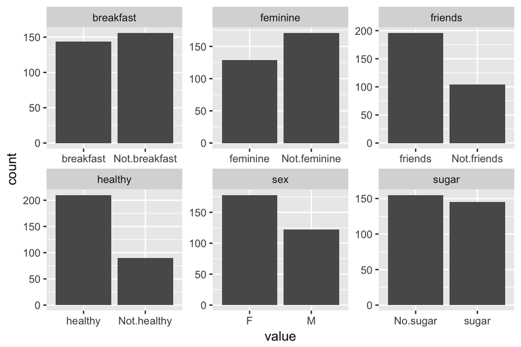

```r
gather(tea_time) %>% ggplot(aes(value)) + facet_wrap("key", scales = "free") + geom_bar()
```

### Analysis

Multiple correspondence analysis is run on the “tea_time” dataset with six variables. The results of the analysis can are displayed below, and the biplot visualizes the results.

```r
mca <- MCA(tea_time, graph = FALSE)
summary(mca)
```

```
##
## Call:
## MCA(X = tea_time, graph = FALSE)
##
##
## Eigenvalues
##                        Dim.1   Dim.2   Dim.3   Dim.4   Dim.5   Dim.6
## Variance               0.247   0.195   0.164   0.158   0.141   0.094
## % of var.             24.729  19.542  16.355  15.807  14.147   9.419
## Cumulative % of var.  24.729  44.271  60.626  76.433  90.581 100.000
##
## Individuals (the 10 first)
##                  Dim.1    ctr   cos2    Dim.2    ctr   cos2    Dim.3
## 1             |  0.727  0.713  0.475 | -0.606  0.626  0.330 |  0.241
## 2             | -0.121  0.020  0.015 | -0.765  0.998  0.608 |  0.241
## 3             | -0.270  0.098  0.103 |  0.112  0.021  0.018 | -0.381
## 4             |  0.682  0.626  0.428 | -0.055  0.005  0.003 |  0.382
## 5             |  0.624  0.525  0.277 | -0.387  0.256  0.107 |  0.504
## 6             |  0.385  0.200  0.140 | -0.308  0.161  0.089 |  0.349
## 7             |  0.328  0.145  0.125 | -0.533  0.485  0.328 | -0.553
## 8             | -0.663  0.593  0.427 | -0.120  0.025  0.014 |  0.597
## 9             |  0.624  0.525  0.277 | -0.387  0.256  0.107 |  0.504
## 10            |  0.431  0.251  0.171 | -0.859  1.258  0.676 |  0.209
##                  ctr   cos2
## 1              0.119  0.052 |
## 2              0.119  0.061 |
## 3              0.295  0.204 |
## 4              0.297  0.134 |
## 5              0.518  0.181 |
## 6              0.249  0.115 |
## 7              0.623  0.354 |
## 8              0.727  0.346 |
## 9              0.518  0.181 |
## 10             0.089  0.040 |
##
## Categories (the 10 first)
##                   Dim.1     ctr    cos2  v.test     Dim.2     ctr    cos2
## No.sugar      |  -0.427   6.352   0.195  -7.636 |  -0.324   4.626   0.112
## sugar         |   0.457   6.790   0.195   7.636 |   0.346   4.945   0.112
## F             |  -0.670  17.969   0.656 -14.001 |   0.101   0.517   0.015
```

[output cut: 12 more lines]

```
## breakfast     -12.627 |  -0.177   1.529   0.029  -2.938 |
## Not.breakfast  12.627 |   0.163   1.412   0.029   2.938 |
## friends         7.106 |  -0.641  27.367   0.775 -15.219 |
## Not.friends    -7.106 |   1.208  51.576   0.775  15.219 |
## healthy        -9.905 |  -0.215   3.292   0.108  -5.674 |
## Not.healthy     9.905 |   0.501   7.682   0.108   5.674 |
##
## Categorical variables (eta2)
##                 Dim.1 Dim.2 Dim.3
## sugar         | 0.195 0.112 0.002 |
## sex           | 0.656 0.015 0.001 |
## breakfast     | 0.005 0.533 0.029 |
## friends       | 0.021 0.169 0.775 |
## healthy       | 0.070 0.328 0.108 |
## feminine      | 0.537 0.015 0.067 |
```

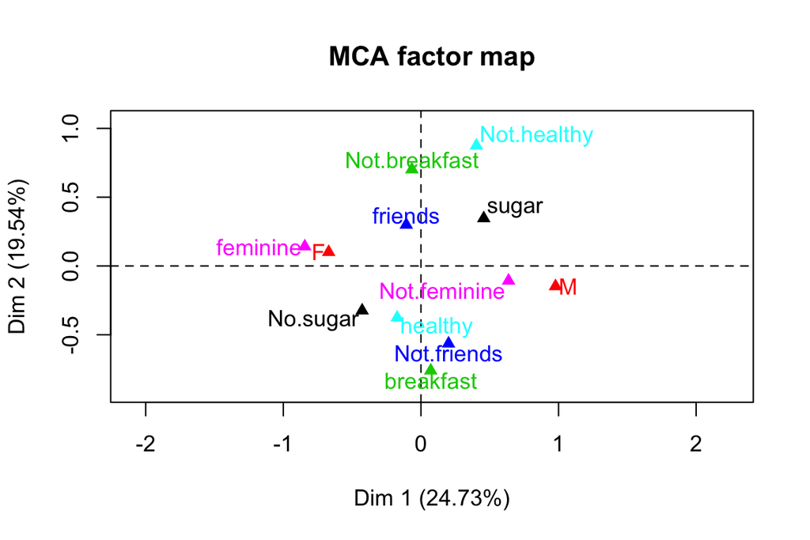

```r
plot(mca, invisible=c("ind"), habillage = "quali")
```

The first two dimensions produced by MCA capture 24.7 % and 19.5 % of the variance in the data. The first dimension is most highly linked to variables “sex”, “feminine” and “sugar” whereas the second dimension is linked to variables “breakfast”, “healthy” and “friends”.

As for the biplot, it shows for example that being male and not considering tea drinking feminine are somewhat close to each other whereas drinking tea with breakfast and without friends are close to each other as well considering tea drinking healthy and drinking it without sugar (meanings of the variables are assumed as I could not find descriptions of them anywhere).